# Project: No-show Appointments Dataset

### What is the relation between Attendance and Age of Patients?

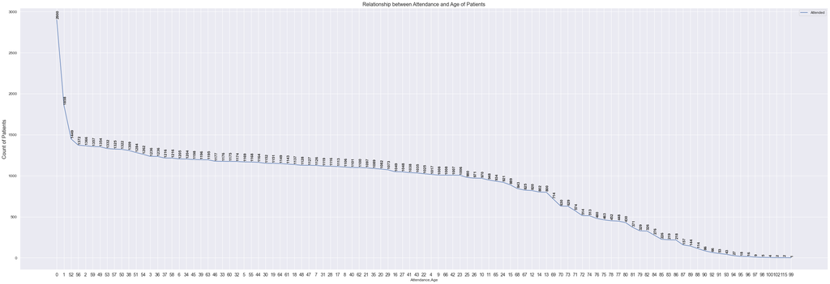

```python
Age_Attended = df[df['Attendance']=='Attended'].groupby('Attendance')['Age'].value_counts()
Age_Attended.plot(figsize=(45,15));


x = []

for i in range(len(Age_Attended.index)):
    (Attendance, Age) = Age_Attended.index[i]
    x.append(Age)


x_ticks = Age_Attended.index
plt.ylabel('Count of Patients', fontsize=font_size1);
plt.title('Relationship between Attendance and Age of Patients', fontsize=font_size1);
plt.xticks(fontsize= font_size2+2, ticks=np.arange(len(x_ticks)), labels=x, rotation='horizontal');
plt.yticks(fontsize= font_size2)
plt.legend(['Attended', 'Missed Appointment']);

for num, value in enumerate(Age_Attended):
    plt.text(num-0.07, value+20, str(value), fontweight='bold', rotation='vertical');
```

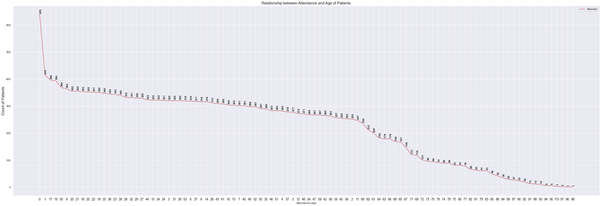

```python
Age_Missed = df[df['Attendance']=='Missed Appointment'].groupby('Attendance')['Age'].value_counts()
Age_Missed.plot(figsize=(45,15), color='r');

x = []

for i in range(len(Age_Missed.index)):
    (Attendance, Age) = Age_Missed.index[i]
    x.append(Age)


x_ticks = Age_Missed.index
plt.ylabel('Count of Patients', fontsize=font_size1);
plt.title('Relationship between Attendance and Age of Patients', fontsize=font_size1);
plt.xticks(fontsize= font_size2+2, ticks=np.arange(len(x_ticks)), labels=x, rotation='horizontal');
plt.yticks(fontsize= font_size2)
plt.legend(['Attended', 'Missed Appointment']);


for num, value in enumerate(Age_Missed):
    plt.text(num-0.07, value+5, str(value), fontweight='bold', rotation='vertical');
```

### What is the relation between Attendance and Gender of Patients?

```
Attendance  Gender
Attended    Female    57245
            Male      30962
Name: Gender, dtype: int64

 Attendance          Gender
Missed Appointment  Female    14594
                    Male       7725
Name: Gender, dtype: int64
```

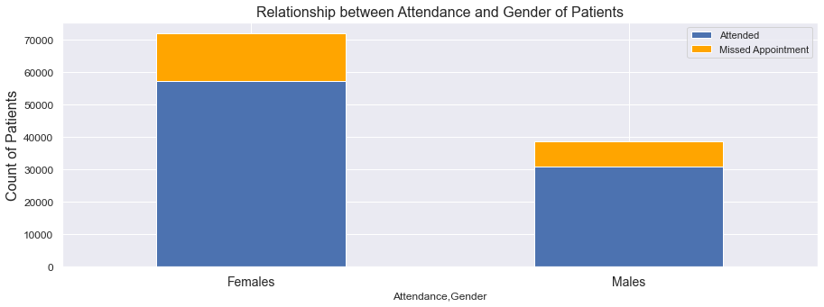

```python
Gender_Attended = df[df['Attendance']=='Attended'].groupby('Attendance')['Gender'].value_counts()
Gender_Attended.plot(kind='bar', figsize=(15,5));
Gender_Missed = df[df['Attendance']=='Missed Appointment'].groupby('Attendance')['Gender'].value_counts()
Gender_Missed.plot(kind='bar', figsize=(15,5), bottom=Gender_Attended, color='orange');

x_ticks = ['Females', 'Males']
plt.ylabel('Count of Patients', fontsize=font_size1);
plt.title('Relationship between Attendance and Gender of Patients', fontsize=font_size1);
plt.xticks(fontsize= font_size2+2, rotation='horizontal', ticks=[0,1], labels=x_ticks);
plt.yticks(fontsize= font_size2)
plt.legend(['Attended', 'Missed Appointment']);

print(Gender_Attended,'\n'*2, Gender_Missed)
```

### What are the speciality of each hospitals depending on the gender?

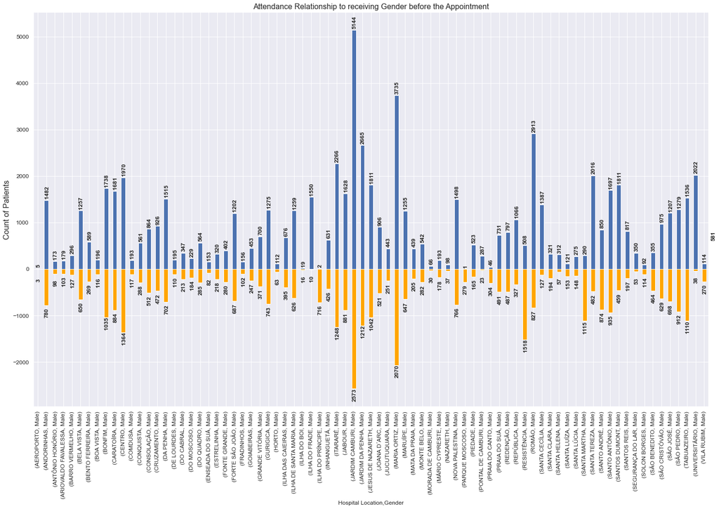

```python
Female_Hospital = df[df['Gender']=='Female'].groupby('Hospital Location')['Gender'].value_counts()
Female_Hospital.plot(kind='bar', figsize=(25,15));
Male_Hospital = df[df['Gender']=='Male'].groupby('Hospital Location')['Gender'].value_counts()*(-1)
Male_Hospital.plot(kind='bar', figsize=(25,15), color='orange');

plt.ylabel('Count of Patients', fontsize=font_size1);
plt.title('Attendance Relationship to receiving Gender before the Appointment', fontsize=font_size1);
plt.xticks(fontsize= font_size2);
plt.yticks(fontsize= font_size2)

for num, value in enumerate(Female_Hospital):
    plt.text(num-0.22, value+50, str(value), fontweight='bold', rotation='vertical');

for num, value in enumerate(Male_Hospital):
    plt.text(num-0.22, value-250, str(value).split('-')[1], fontweight='bold', rotation='vertical');
```

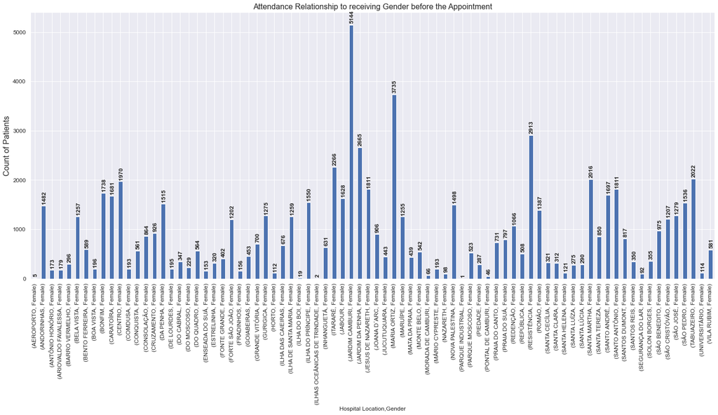

```python
Female_Hospital = df[df['Gender']=='Female'].groupby('Hospital Location')['Gender'].value_counts()
Female_Hospital.plot(kind='bar', figsize=(25,10));

plt.ylabel('Count of Patients', fontsize=font_size1);
plt.title('Attendance Relationship to receiving Gender before the Appointment', fontsize=font_size1);
plt.xticks(fontsize= font_size2);
plt.yticks(fontsize= font_size2)

# print(Female_Hospital.nlargest(5))

for num, value in enumerate(Female_Hospital):
    plt.text(num-0.2, value+50, str(value), fontweight='bold', rotation='vertical');
```

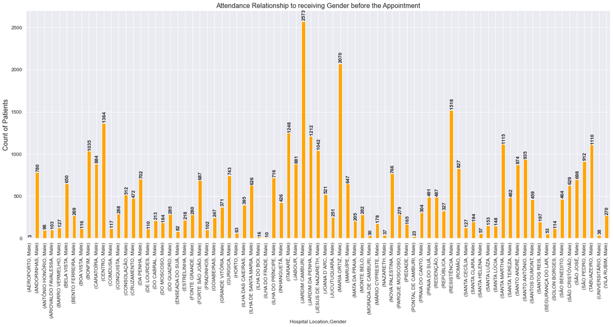

```python
Male_Hospital = df[df['Gender']=='Male'].groupby('Hospital Location')['Gender'].value_counts()
Male_Hospital.plot(kind='bar', figsize=(25,10), color='orange');

plt.ylabel('Count of Patients', fontsize=font_size1);
plt.title('Attendance Relationship to receiving Gender before the Appointment', fontsize=font_size1);
plt.xticks(fontsize= font_size2);
plt.yticks(fontsize= font_size2)

# Male_Hospital.nlargest(5)

for num, value in enumerate(Male_Hospital):
    plt.text(num-0.2, value+20, str(value), fontweight='bold', rotation='vertical');
```

### What is the relation between Age and Gender?

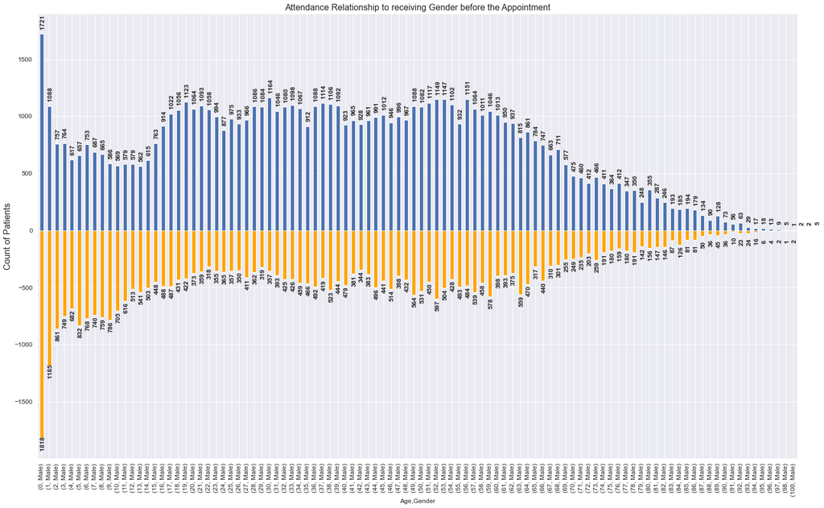

```python
Female_Age = df[df['Gender']=='Female'].groupby('Age')['Gender'].value_counts()
Female_Age.plot(kind='bar', figsize=(25,15));
Male_Age = df[df['Gender']=='Male'].groupby('Age')['Gender'].value_counts()*(-1)
Male_Age.plot(kind='bar', figsize=(25,15), color='orange');

plt.ylabel('Count of Patients', fontsize=font_size1);
plt.title('Attendance Relationship to receiving Gender before the Appointment', fontsize=font_size1);
plt.xticks(fontsize= font_size2);
plt.yticks(fontsize= font_size2)

for num, value in enumerate(Female_Age):
    plt.text(num-0.22, value+50, str(value), fontweight='bold', rotation='vertical');

for num, value in enumerate(Male_Age):
    plt.text(num-0.22, value-100, str(value).split('-')[1], fontweight='bold', rotation='vertical');
```

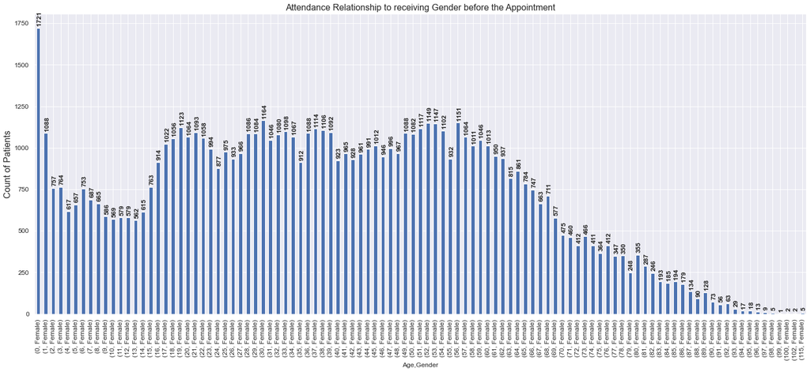

```python
Female_Hospital = df[df['Gender']=='Female'].groupby('Age')['Gender'].value_counts()
Female_Hospital.plot(kind='bar', figsize=(25,10));

plt.ylabel('Count of Patients', fontsize=font_size1);
plt.title('Attendance Relationship to receiving Gender before the Appointment', fontsize=font_size1);
plt.xticks(fontsize= font_size2);
plt.yticks(fontsize= font_size2)

# Male_Hospital.nlargest(5)

for num, value in enumerate(Female_Hospital):
    plt.text(num-0.2, value+20, str(value), fontweight='bold', rotation='vertical');
```

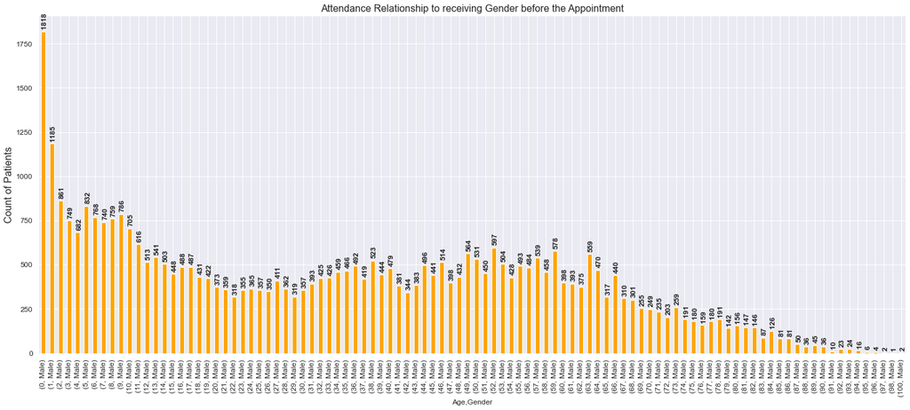

```python
Male_Hospital = df[df['Gender']=='Male'].groupby('Age')['Gender'].value_counts()
Male_Hospital.plot(kind='bar', figsize=(25,10), color='orange');

plt.ylabel('Count of Patients', fontsize=font_size1);
plt.title('Attendance Relationship to receiving Gender before the Appointment', fontsize=font_size1);
plt.xticks(fontsize= font_size2);
plt.yticks(fontsize= font_size2)

# Male_Hospital.nlargest(5)

for num, value in enumerate(Male_Hospital):
    plt.text(num-0.2, value+20, str(value), fontweight='bold', rotation='vertical');
```

## Conclusions

- We found that patients who have recieved an SMS for the appointment have more chance to attend, as patients who recieved SMS and missed the appointment are only 27.6% of total patients who recieved SMS.
- We found that patients who have recieved an SMS for the appointment have more chance to attend, as patients who recieved SMS and missed the appointment are only 27.6% of total patients who recieved SMS.
- We found that patients who have Diabetes have a small chance to miss his appointment, as the percentage of patients who missed their appointment with Diabetes is less than those healthy ones by 1%.
- We found that patients who have hypertension have a small chance to miss his appointment, as the percentage of patients who miss their appointment with hypertension is less than those healthy ones by 3.5%.
- We found that patients who have family allowance have a higher chance to miss their appointment, as the percentage of patients who missed their appointment is more than those who attended by 2.2%.
- We found that work days had attendance more than weekends, and hospitals has no appointments at Sundays. The highest day of appointments is Wednesday by 25867 appointments followed by Tuesday by 25640 appointments, and the least one is Saturday with total 39 appointments.
- We found that less males have family allowance than females, as 11.8% of females have family allowance but only 5% of males have it. Also found when comparing attendance and its relation to family allowance we will find that more patients who have family allowance tend to miss their appointment more than patients without it, as 5% of males attended at time but 6.1% missed the appointment, and for females 11.8% attended but 14.4% missed the appointment.

## Submitting your Project

> Before you submit your project, you need to create a .html or .pdf version of this notebook in the workspace here. To do that, run the code cell below. If it worked correctly, you should get a return code of 0, and you should see the generated .html file in the workspace directory (click on the orange Jupyter icon in the upper left).

> Alternatively, you can download this report as .html via the **File** > **Download as** submenu, and then manually upload it into the workspace directory by clicking on the orange Jupyter icon in the upper left, then using the Upload button.

> Once you've done this, you can submit your project by clicking on the "Submit Project" button in the lower right here. This will create and submit a zip file with this .ipynb doc and the .html or .pdf version you created. Congratulations!

```python
from subprocess import call
call(['python', '-m', 'nbconvert', 'Investigate_a_Dataset.ipynb'])
```

```
4294967295
```